# PCA

## Introduction

This script performs PCA to see how similar our samples are, then plot the results using PCA biplot.

## Load necessary libraries.

```r
# if(!requireNamespace("BiocManager")){
#   install.packages("BiocManager")
# }
# BiocManager::install("phyloseq")
# install.packages(c("tidyverse","vegan","Polychrome"))
library(tidyverse)
library(vegan) # Need v2.6-4 instead of current (2.7-1)
```

## Specifying parameters and directory/file names.

```r
# cmdargs <- commandArgs(trailingOnly = TRUE)
# active.analysis <- cmdargs[1]
unlockBinding("params", env = .GlobalEnv)
active.analysis <- params$active.analysis
print(paste("The analysis focus is:", active.analysis))
```

```
## [1] "The analysis focus is: all_domains"
```

```r
source(here::here("config/R/config.R"))# config file with global variables
source(here::here("config/R/themes.R"))# config file with themes

dir.create(diversity.tables,recursive = TRUE)
dir.create(diversity.rdafiles,recursive = TRUE)
```

```r
dir.create(file.path(diversity.figures, "pca"),recursive = TRUE)
dir.create(file.path(diversity.figures, "alpha"),recursive = TRUE)
plot.types<-c("plot"="",
              "plot.with.labels"="-with-labels")
```

The taxonomic rank that was used for agglomeration:

```r
agglom.rank<-"Genus"
ps.q.agg<-readRDS(file=file.path(
  community.composition.rdafiles,
  paste("phyloseq-qiime",authorname,agglom.rank,read.end.type,
        truncationlvl,"table.rds",sep = "-")))
custom.md <- readRDS(custom.md.path)
custom.levels<-intersect(names(pretty.level.names),custom.md$class)
```

Remove rows with 0 Abundance, if there’s any.

```r
ps.q.agg<-ps.q.agg%>%
    filter(class%in%custom.levels,Abundance!=0)
```

## PCA

Import rarefied dataframe.

```r
ps.q.df.pca.input<-readRDS(
  file.path(community.composition.rdafiles,
            paste0(
    paste("ps.q.df.rare-nonfiltered",agglom.rank,
      paste(custom.levels,collapse = '-'),sep = "-"),
    ".rds")))
```

Convert into wide format.

```r
ps.q.df.wide.pca<-ps.q.df.pca.input%>%
  dplyr::select(all_of(c(agglom.rank,"Sample","Abundance")))%>%
  pivot_wider(names_from = all_of(agglom.rank),
              values_from = "Abundance",
              values_fill = 0)%>%
  as.data.frame()
```

Column names are ASVs and row names are sample IDs.

```r
rownames(ps.q.df.wide.pca)<-ps.q.df.wide.pca$Sample
```

Remove the Sample column (the first column)

```r
ps.q.df.wide.pca<-ps.q.df.wide.pca[,-1]
ps.q.df.wide.pca<-as.matrix(ps.q.df.wide.pca)
```

The first crucial step is to transform the compositional data: Use a log-ratio transformation, typically the centered log-ratio (clr) or isometric log-ratio (ilr) transformation. The clr transformation is often preferred for interpretability, while ilr is used for statistical properties. We will use robust CLR (RCLR) with natural log.

```r
ps.q.df.wide.pca.tfm<-decostand(ps.q.df.wide.pca,
                                method="rclr",
                                logbase = exp)
```

Calculate principal components

```r
pca.q<-prcomp(ps.q.df.wide.pca.tfm)
str(pca.q)
```

```
## List of 5
##  $ sdev    : num [1:99] 7.02 5.51 4.93 3.81 3.42 ...
##  $ rotation: num [1:458, 1:99] -0.02004 -0.07707 -0.18114 -0.00365 0.01449 ...
##   ..- attr(*, "dimnames")=List of 2
##   .. ..$ : chr [1:458] "Clostridium_sensu_stricto_1" "Lachnospiraceae Family" "Ruminococcus" "Akkermansia" ...
##   .. ..$ : chr [1:99] "PC1" "PC2" "PC3" "PC4" ...
##  $ center  : Named num [1:458] -0.0516 3.2707 1.1252 -0.0438 -0.1973 ...
##   ..- attr(*, "names")= chr [1:458] "Clostridium_sensu_stricto_1" "Lachnospiraceae Family" "Ruminococcus" "Akkermansia" ...
##  $ scale   : logi FALSE
##  $ x       : num [1:99, 1:99] -3.441 -3.627 -3.207 0.541 -4.297 ...
##   ..- attr(*, "dimnames")=List of 2
##   .. ..$ : chr [1:99] "MF_153" "MF_144" "MF_143" "F568" ...
##   .. ..$ : chr [1:99] "PC1" "PC2" "PC3" "PC4" ...
##  - attr(*, "class")= chr "prcomp"
```

- `sdev` is standard deviations of principal components. Used to construct the scree plot
- `rotation` is loadings
- `center` is values used for centering  
  `x` is scores (original data in the new coordinate system) s

```r
dim(pca.q$x)
```

```
## [1] 99 99
```

### Scree plot.

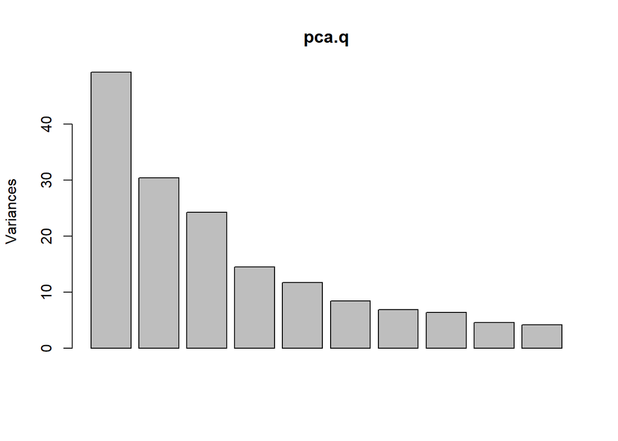

```r
plot(pca.q)
```

Calculate total variance explained by each principal component.

```r
pca.q$sdev^2 / sum(pca.q$sdev^2)
```

```
##  [1] 1.733820e-01 1.069984e-01 8.541600e-02 5.112604e-02 4.113114e-02 2.949041e-02 2.409460e-02 2.251470e-02 1.616894e-02 1.465371e-02 1.397390e-02 1.374625e-02 1.297599e-02
## [14] 1.249228e-02 1.185854e-02 1.149660e-02 1.126561e-02 1.045579e-02 1.019972e-02 9.971874e-03 9.675401e-03 9.009240e-03 8.916774e-03 8.707487e-03 8.554188e-03 8.224343e-03
## [27] 8.070477e-03 7.919999e-03 7.802281e-03 7.474869e-03 7.210212e-03 7.035995e-03 6.961144e-03 6.815437e-03 6.527292e-03 6.509018e-03 6.465775e-03 6.217346e-03 5.981266e-03
## [40] 5.908944e-03 5.894378e-03 5.604231e-03 5.513929e-03 5.371859e-03 5.216921e-03 4.992715e-03 4.960645e-03 4.814290e-03 4.745872e-03 4.639294e-03 4.485420e-03 4.320100e-03
## [53] 4.275596e-03 4.114257e-03 3.940861e-03 3.876212e-03 3.858657e-03 3.699975e-03 3.640550e-03 3.422674e-03 3.393603e-03 3.296208e-03 3.210522e-03 3.140764e-03 3.113049e-03
## [66] 2.977169e-03 2.960270e-03 2.853508e-03 2.761287e-03 2.648298e-03 2.593473e-03 2.556220e-03 2.447702e-03 2.419205e-03 2.356060e-03 2.263131e-03 2.098197e-03 2.079239e-03
## [79] 2.007634e-03 1.934614e-03 1.830041e-03 1.751164e-03 1.723429e-03 1.632887e-03 1.518889e-03 1.454750e-03 1.374925e-03 1.333145e-03 1.230952e-03 1.187224e-03 1.147302e-03
## [92] 1.068048e-03 1.023004e-03 9.428684e-04 9.157801e-04 7.232210e-04 6.523788e-04 5.914083e-04 3.419357e-32
```

Calculate total variance explained by each principal component.

```r
var_explained = pca.q$sdev^2 / sum(pca.q$sdev^2)
```

Create a scree plot:

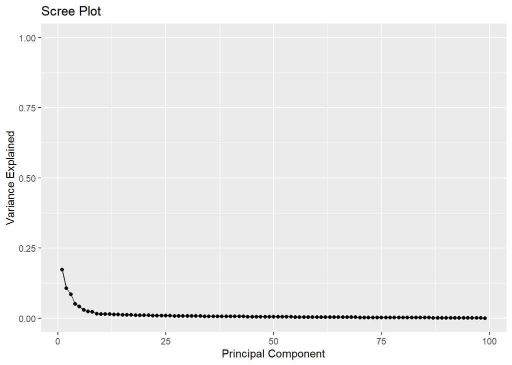

```r
qplot(seq_along(1:nrow(ps.q.df.wide.pca.tfm)), var_explained) +
  geom_line() +
  xlab("Principal Component") +
  ylab("Variance Explained") +
  ggtitle("Scree Plot") +
  ylim(0, 1)
```

### Loading plot.

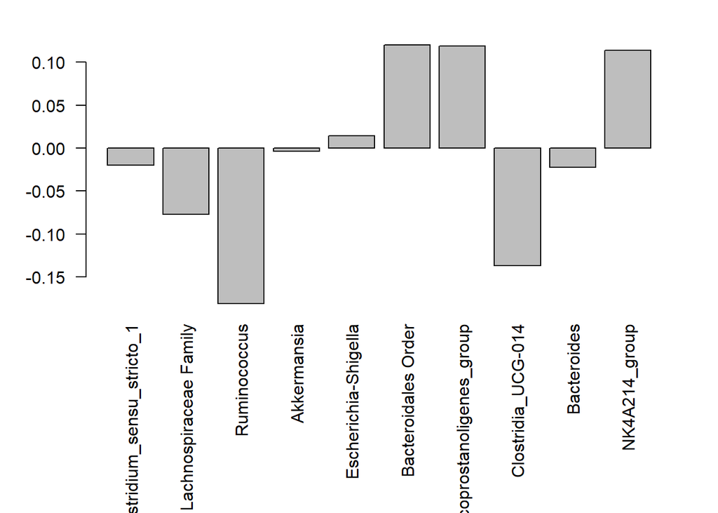

```r
par(mar = c(10, 4, 2, 2) + 0.2) #
barplot(pca.q$rotation[1:10,1],las=2)
```

Display principal components (loadings):

```r
head(pca.q$rotation[,1:10])
```

```
##                                     PC1          PC2          PC3         PC4         PC5         PC6         PC7          PC8         PC9         PC10
## Clostridium_sensu_stricto_1 -0.02003998  0.032999253  0.055920559 -0.06038047 -0.02862909  0.09045755 -0.06495700  0.111528437 -0.05404731  0.087042883
## Lachnospiraceae Family      -0.07706706 -0.097198206  0.020632671  0.02588184  0.12815665 -0.10350545  0.04236218 -0.079098307  0.01837018 -0.123598289
## Ruminococcus                -0.18114413 -0.058454281  0.299429894  0.05319085  0.03847871 -0.05739379  0.03430445 -0.028859476 -0.13124103  0.072999577
## Akkermansia                 -0.00365467  0.032927345  0.096321320 -0.04849225 -0.13422316  0.12873039 -0.15965610 -0.008196061  0.11002207 -0.065170100
## Escherichia-Shigella         0.01449209 -0.001626054 -0.003449642  0.04880891 -0.03985398  0.03360374 -0.01004323  0.003812556  0.01969335  0.009708758
## Bacteroidales Order          0.12015133  0.074317642  0.111613478  0.22087588  0.17526728  0.07154348 -0.03751998  0.173500096 -0.03066420 -0.022253630
```

Display the first six scores:

```r
head(pca.q$x[,1:10])
```

```
##               PC1        PC2       PC3        PC4        PC5         PC6        PC7        PC8        PC9       PC10
## MF_153 -3.4408692  1.2167788  7.711237 -4.7701624 -5.7355586  3.31119799 -2.3094869  2.3220247 -2.3841233  2.7323779
## MF_144 -3.6271190  1.6413246 11.136617 -0.5540691 -6.2494921  3.76964866 -1.8215893  3.4458786  2.9651584  0.1755018
## MF_143 -3.2074684  0.7761617  8.737931 -6.0500796 -7.7619557  4.59822749 -3.2327857  0.8722518  2.4826478 -0.7949120
## F568    0.5408425  9.6012954 -2.845548  1.0483719  1.2767877 -0.20827303  0.4476028 -1.0397530 -1.7827279  0.5291265
## MF_136 -4.2972827 -2.0847060  5.887731  7.8602677  1.8941954 -0.05632915 -0.1188570  1.1196419  1.9737681 -2.5216721
## F541    1.2015965 10.2792112 -3.363419  2.3042865 -0.6537825 -0.69241787 -1.1463646  0.1400209  0.2886558 -0.4828867
```

## PCA Plot.

```r
PC1<-pca.q$x[,1]
PC2<-pca.q$x[,2]
```

Check how much variance is explained by the first two principal components:

```r
perc.var<-round(100*summary(pca.q)$importance[2,1:2],2)
perc.var
```

```
##   PC1   PC2
## 17.34 10.70
```

Combine the principal component vectors into a dataframe:

```r
PC1.df <- as.data.frame(PC1)%>%
  mutate(Sample = rownames(ps.q.df.wide.pca))
PC2.df <- as.data.frame(PC2)%>%
  mutate(Sample = rownames(ps.q.df.wide.pca))
```

Plot the PCA results:

```r
pca.plot<-PC1.df%>%
  left_join(PC2.df)%>%
  left_join(custom.md)%>%
  mutate(class = factor(class, levels=custom.levels))%>%
  group_by(class)%>%
  mutate(class_id = cur_group_id(), # add numeric id
         class_name = pretty.level.names[class_id])%>%
  ggplot(aes(x = PC1,
             y = PC2,
             color = class_name,
             fill = class_name)) +
  geom_point(aes(shape = class_name),
             size = 2,
             color = "black")+
  scale_shape_manual(values = 0:9,
                     breaks = pretty.level.names,
                     labels = unname(pretty.level.names))+
  stat_ellipse(geom = "polygon",
               level = 0.8,
               alpha = 0.2,
               show.legend = FALSE,
               color = "black")+
  scale_fill_viridis_d(option = "C",
                       labels = unname(pretty.level.names))+
  theme_bw()+
  # ggtitle(paste0("PCA between different rodents (",agglom.rank, " level)"))+
  labs(x = paste0("PC1 (", perc.var[1], "%)"),
       y = paste0("PC2 (", perc.var[2], "%)"),
       shape = "Host")+
  guides(fill="none")+
  project_theme + # general theme
  pca.plot.theme+
  theme(legend.position = "bottom")+
  labs(shape ="")
```

Label each point by sample name:

```r
pca.plot.with.labels<-pca.plot+
  ggrepel::geom_text_repel(aes(label = Sample),
                           show.legend = FALSE,
                           color = "black")
```

```
## Too few points to calculate an ellipse
```

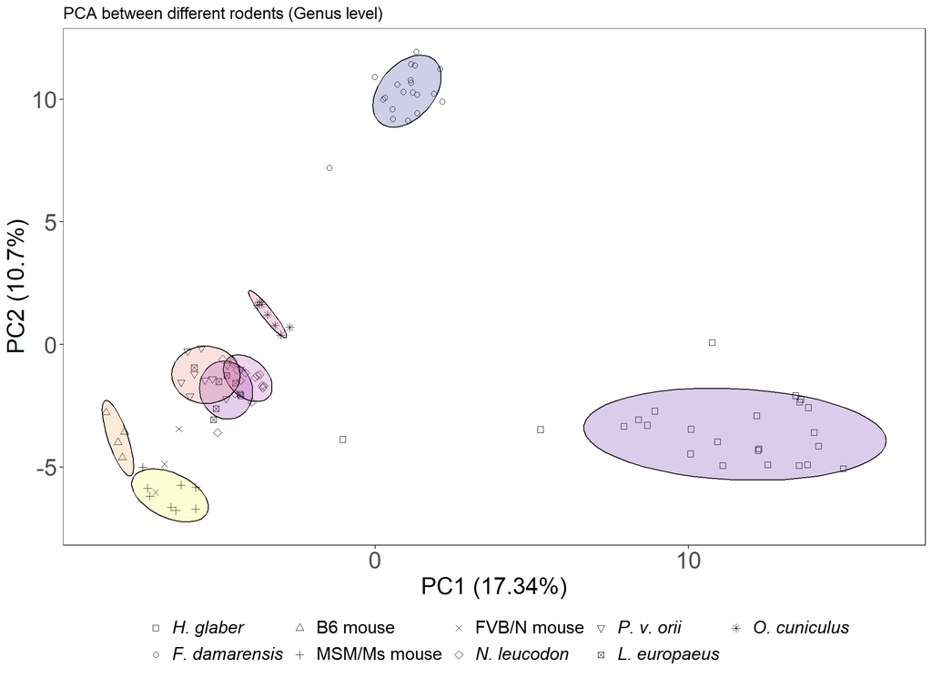

```r
print(pca.plot +
        ggtitle(paste0("PCA between different rodents (",agglom.rank, " level)"))+
        theme(plot.title = element_text(size = 14)))
```

```
## Too few points to calculate an ellipse
```

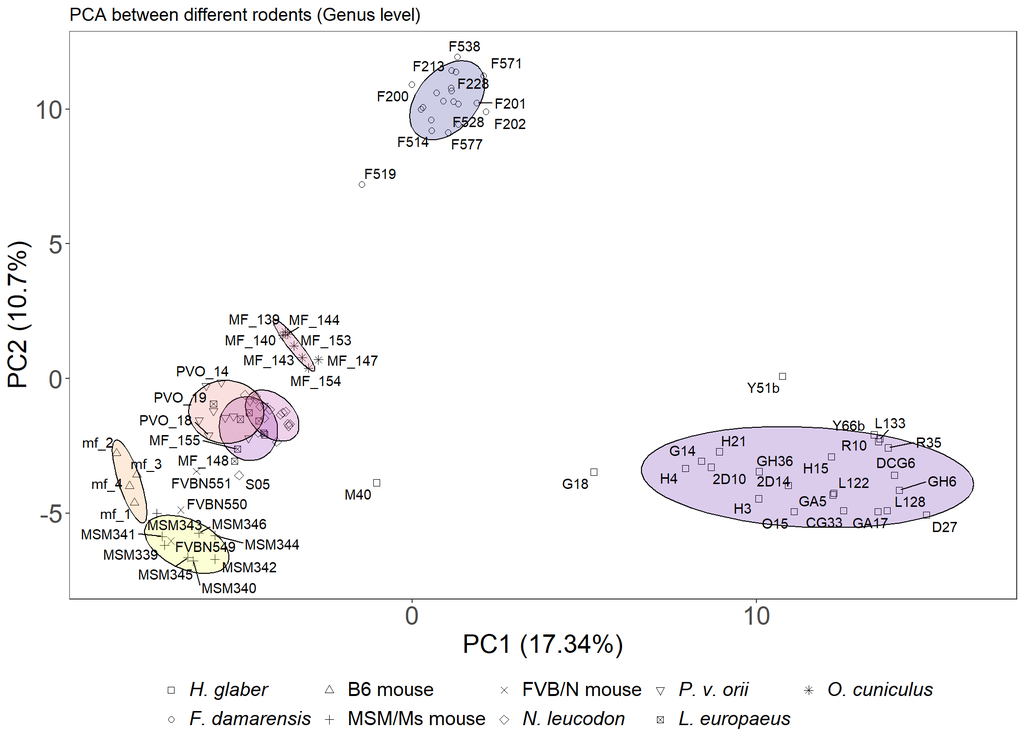

```r
print(pca.plot.with.labels +
        ggtitle(paste0("PCA between different rodents (",agglom.rank, " level)"))+
        theme(plot.title = element_text(size = 14)))
```

```r
# Save the plots
for(plot.type in seq_along(plot.types)){
  for(image.format in image.formats){
    ggsave(filename = paste0(paste(
                        "pca",
                        paste(custom.levels,collapse = '-'),
                        agglom.rank,truncationlvl,sep = "-"),
                  plot.types[plot.type], ".",image.format),
           path = file.path(diversity.figures,"pca"),
           plot=get(paste0("pca.",names(plot.types[plot.type]))),
           width=11, height=8,units="in",
           dpi=300,device = image.format)
  }
}
```

```
## Too few points to calculate an ellipse
## Too few points to calculate an ellipse
## Too few points to calculate an ellipse
```

```
## Too few points to calculate an ellipse
```

## Find ASVs that contribute to PCs.

```r
aload<-abs(pca.q$rotation)
```

Below, 2 means columns; sweep divides each column of loadings and divides by the column sum.

```r
head(sweep(aload,2,colSums(aload),"/"))[1:5,1:5]
```

```
##                                     PC1          PC2          PC3         PC4         PC5
## Clostridium_sensu_stricto_1 0.001753309 0.0028138171 0.0048376377 0.005269839 0.002374085
## Lachnospiraceae Family      0.006742638 0.0082880051 0.0017849140 0.002258895 0.010627472
## Ruminococcus                0.015848397 0.0049843449 0.0259034135 0.004642350 0.003190872
## Akkermansia                 0.000319749 0.0028076856 0.0083326717 0.004232269 0.011130541
## Escherichia-Shigella        0.001267920 0.0001386522 0.0002984254 0.004259906 0.003304917
```

```r
colSums(sweep(aload, 2, colSums(aload), "/"))
```

```
##  PC1  PC2  PC3  PC4  PC5  PC6  PC7  PC8  PC9 PC10 PC11 PC12 PC13 PC14 PC15 PC16 PC17 PC18 PC19 PC20 PC21 PC22 PC23 PC24 PC25 PC26 PC27 PC28 PC29 PC30 PC31 PC32 PC33 PC34
##    1    1    1    1    1    1    1    1    1    1    1    1    1    1    1    1    1    1    1    1    1    1    1    1    1    1    1    1    1    1    1    1    1    1
## PC35 PC36 PC37 PC38 PC39 PC40 PC41 PC42 PC43 PC44 PC45 PC46 PC47 PC48 PC49 PC50 PC51 PC52 PC53 PC54 PC55 PC56 PC57 PC58 PC59 PC60 PC61 PC62 PC63 PC64 PC65 PC66 PC67 PC68
##    1    1    1    1    1    1    1    1    1    1    1    1    1    1    1    1    1    1    1    1    1    1    1    1    1    1    1    1    1    1    1    1    1    1
## PC69 PC70 PC71 PC72 PC73 PC74 PC75 PC76 PC77 PC78 PC79 PC80 PC81 PC82 PC83 PC84 PC85 PC86 PC87 PC88 PC89 PC90 PC91 PC92 PC93 PC94 PC95 PC96 PC97 PC98 PC99
##    1    1    1    1    1    1    1    1    1    1    1    1    1    1    1    1    1    1    1    1    1    1    1    1    1    1    1    1    1    1    1
```

```r
colSums(aload)
```

```
##      PC1      PC2      PC3      PC4      PC5      PC6      PC7      PC8      PC9     PC10     PC11     PC12     PC13     PC14     PC15     PC16     PC17     PC18     PC19
## 11.42981 11.72758 11.55948 11.45774 12.05900 12.01779 12.40862 11.96402 12.85491 14.20120 13.89277 14.00159 14.20981 14.35543 14.92333 14.35020 14.01676 14.68019 14.72068
##     PC20     PC21     PC22     PC23     PC24     PC25     PC26     PC27     PC28     PC29     PC30     PC31     PC32     PC33     PC34     PC35     PC36     PC37     PC38
## 14.49689 14.51731 15.80300 14.97102 15.37078 14.97220 15.43862 14.83295 15.29268 15.38819 15.82867 14.84137 15.31269 15.46427 15.49261 15.45561 15.28329 16.24431 15.09920
##     PC39     PC40     PC41     PC42     PC43     PC44     PC45     PC46     PC47     PC48     PC49     PC50     PC51     PC52     PC53     PC54     PC55     PC56     PC57
## 15.55891 15.56911 15.31368 14.63412 15.11286 16.12419 16.12448 15.80347 15.25444 15.64349 15.52168 15.27653 15.54729 16.29470 16.01846 15.89936 15.23738 15.54882 16.14579
##     PC58     PC59     PC60     PC61     PC62     PC63     PC64     PC65     PC66     PC67     PC68     PC69     PC70     PC71     PC72     PC73     PC74     PC75     PC76
## 15.47706 15.50006 15.48323 15.46221 15.77910 15.91556 15.84725 15.46983 15.88982 15.14895 16.14638 15.38871 15.77821 15.31186 15.39116 16.23986 15.52856 16.15795 15.18467
##     PC77     PC78     PC79     PC80     PC81     PC82     PC83     PC84     PC85     PC86     PC87     PC88     PC89     PC90     PC91     PC92     PC93     PC94     PC95
## 15.82461 16.45584 15.78030 14.97795 15.93530 15.80954 15.88855 15.93147 15.92111 16.26901 15.78306 15.96921 16.18270 15.68433 15.65242 15.34017 15.14486 15.51207 15.67784
##     PC96     PC97     PC98     PC99
## 13.83864 14.91394 13.85280 13.65716
```

```r
aload[1,1]/colSums(aload)[1]
```

```
##         PC1
## 0.001753309
```

```r
pc.df<-as.data.frame(sweep(aload,2,colSums(aload),"/")[,1:2])
lapply(pc.df,max)
```

```
## $PC1
## [1] 0.02050968
##
## $PC2
## [1] 0.023398
```

```r
max.ind<-lapply(pc.df,which.max)
pc.df[max.ind$PC1,]
```

```
##                                   PC1         PC2
## Erysipelotrichaceae Family 0.02050968 0.009982139
```

```r
pc.df[max.ind$PC2,]
```

```
##                              PC1      PC2
## Rikenellaceae Family 0.001597289 0.023398
```

```r
pc1.loadings<-pc.df%>%
  rownames_to_column(var=agglom.rank)%>%
  arrange(-PC1)%>%
  mutate(PC_num="PC1")%>%
  head()
pc2.loadings<-pc.df%>%
  rownames_to_column(var=agglom.rank)%>%
  arrange(-PC2)%>%
  mutate(PC_num="PC2")%>%
  head()

pc1.loadings$Genus
```

```
## [1] "Erysipelotrichaceae Family" "Prevotellaceae_UCG-003"     "Prevotella"                 "p-251-o5"                   "Prevotellaceae Family"
## [6] "Fibrobacter"
```

```r
pc2.loadings$Genus
```

```
## [1] "Rikenellaceae Family"   "Bacteroidia Class"      "Prevotella"             "Gastranaerophilales"    "Eggerthellaceae Family" "Prevotellaceae_UCG-001"
```

```r
loadings.df<-pc1.loadings%>%
  rbind(pc2.loadings)%>%
  dplyr::select(-PC1,-PC2)%>%
  add_count(Genus)%>%
  mutate(PC_num=ifelse(n==2,"PC1_and_PC2",PC_num))%>%
  distinct(Genus,PC_num)
loadings.df
```

```
##                         Genus      PC_num
## 1  Erysipelotrichaceae Family         PC1
## 2      Prevotellaceae_UCG-003         PC1
## 3                  Prevotella PC1_and_PC2
## 4                    p-251-o5         PC1
## 5       Prevotellaceae Family         PC1
## 6                 Fibrobacter         PC1
## 7        Rikenellaceae Family         PC2
## 8           Bacteroidia Class         PC2
## 9         Gastranaerophilales         PC2
## 10     Eggerthellaceae Family         PC2
## 11     Prevotellaceae_UCG-001         PC2
```

Check if the loadings are found in the data:

```r
source("./code/r-scripts/add_relab_to_tax_df.R")
ps.q.agg.pc_loadings<-add_relab_to_tax_df(ps.q.agg,"Genus")%>%
  distinct(class,Genus,MeanRelativeAbundance,sdRelativeAbundance)%>%
  right_join(loadings.df)
# write.table(ps.q.agg.pc_loadings,
#             file=file.path(rtables.directory,
#                            paste(paste(format(Sys.time(),format="%Y%m%d"),
#                                        format(Sys.time(),format = "%H_%M_%S"),sep = "_"),
#                                  "pca-loadings-mean_relative_abundance.tsv",sep="-")),
#             row.names = F,sep = "\t")
ps.q.agg.pc_loadings
```

```
## # A tibble: 60 × 5
##    class Genus                      MeanRelativeAbundance sdRelativeAbundance PC_num
##    <fct> <chr>                                      <dbl>               <dbl> <chr>
##  1 DMR   Prevotella                                 14.2                 8.60 PC1_and_PC2
##  2 DMR   Prevotellaceae Family                       9.26                4.94 PC1
##  3 DMR   Bacteroidia Class                           4.99                5.63 PC2
##  4 DMR   Rikenellaceae Family                        4.28                5.95 PC2
##  5 NMR   Fibrobacter                                 5.71                5.00 PC1
##  6 DMR   Gastranaerophilales                         2.48                1.34 PC2
##  7 NMR   Erysipelotrichaceae Family                  5.53                4.57 PC1
##  8 NMR   p-251-o5                                    6.32                3.73 PC1
##  9 NMR   Prevotellaceae_UCG-003                      5.48                2.65 PC1
## 10 NMR   Prevotellaceae_UCG-001                      4.63                2.86 PC2
## # ℹ 50 more rows
```

```r
rm(list =setdiff(ls(all.names = TRUE), "active.analysis"))
gc()
```

```
##            used  (Mb) gc trigger  (Mb) max used  (Mb)
## Ncells  7543692 402.9   12980266 693.3 12980266 693.3
## Vcells 16607876 126.8   53423703 407.6 83474534 636.9
```